# Advanced Monte Carlo Methods

Manuel D. Rossetti, PhD P.E.

## Learning Objectives

- To be able to explain and apply the basic principles of bootstrap sampling
- To be able to apply variance reduction techniques to simulation experiments
- To be able to apply the main techniques recommended for generating multi-variate random variables
- To be able to apply Markov Chain Monte Carlo (MCMC) techniques to the generation of random variables

## What is Bootstrapping?

- Bootstrapping is a statistical procedure that **resamples from a sample** to create many simulated samples.
- It is generally a *non-parametric* Monte Carlo method that estimates characteristics of a population by resampling.
- Recall a **random sample** $x_1, x_2,\cdots,x_n$: the $X_i$ are independent and every $X_i$ has the same distribution, drawn from some *population*.
- **The fundamental principle:** we *assume* the original random sample is *essentially* the population. Sampling from the sample is, in essence, sampling from the population.
- If the original sample is representative of the true population, then statistics computed from resamples provide observations of the **sampling distribution** of the estimator.

## The Bootstrap Principle and the Empirical Distribution

- Let $F$ be the CDF of $X$, and let $\theta = t(F)$ be a population parameter of interest (mean, median, correlation, $\dots$).
- We usually do not know $F$, but the sample $\vec{x}=(x_1,\cdots,x_n)$ gives the **empirical distribution** $F_n$, an estimate of $F$.
- Define $X^{*}$ as a value drawn at random from $(x_1,\cdots,x_n)$, so $P(X^{*}=x_i)=1/n$. A **bootstrap sample** $\vec{x}^{*}=(x^{*}_1,\cdots,x^{*}_n)$ is drawn *with replacement* — values may repeat.
- Let $\hat{\theta}^{*}_b$ be the estimator evaluated on the $b^{th}$ bootstrap sample, $b=1,\cdots,B$. These are the **bootstrap replicates**.
- The empirical distribution of $(\hat{\theta}^{*}_1,\cdots,\hat{\theta}^{*}_B)$ approximates the sampling distribution of $\hat{\theta}$ — its quality depends entirely on the quality of the original sample.

## Standard Error, Bias, and Confidence Intervals

- **Bootstrap standard error** — the sample standard deviation of the replicates:
  $$\widehat{se(\hat{\theta})} = \sqrt{\tfrac{1}{B-1}\textstyle\sum_{b=1}^{B}\big(\hat{\theta}^{*}_{b} - \bar{\hat{\theta^{*}}} \big)^2}, \qquad \widehat{bias}(\hat{\theta}) = \bar{\hat{\theta^{*}}} - \hat{\theta}$$
- CIs derive from the distribution of $\hat{\theta} - \theta$: $\;\hat{\theta}-\gamma_{1-\alpha/2} \leq \theta \leq \hat{\theta} - \gamma_{\alpha/2}$. Five approximate intervals are used:
  - standard normal (SNBCI), basic (BBCI), percentile (BPCI), **bias-corrected & accelerated (BCa)**, and bootstrap-t (BTCI)
- The percentile interval is popular, but **BCa is recommended** — it corrects the percentile interval for bias and skewness. Bootstrap-t is next, but needs an extra inner resampling step (except when $\hat{\theta}=\bar{x}$).
- Guidance on the number of resamples $B$: at least in the hundreds; $B \approx 40n$ has been suggested.

## Bootstrapping “by Hand” with `DPopulation`

- Bootstrapping is just sampling again and again from a discrete population. The KSL `DPopulation` class is a natural starting point.
- Treat the original size-10 sample as the pseudo-population and resample size 10 **with replacement**.

```kotlin
// mainSample = doubleArrayOf(6.0, 7.0, 5.0, 1.0, 0.0, 4.0, 6.0, 0.0, 6.0, 1.0)
val samplePopulation = DPopulation(mainSample)
val bootStrapAverages = mutableListOf<Double>()
for (i in 1..10) {
    val bootStrapSample = samplePopulation.sample(10)   // resample size n, with replacement
    bootStrapAverages.add(bootStrapSample.average())
}
// percentile-based 90% bootstrap CI on the original estimate (x̄ = 3.6)
val lcl = Statistic.percentile(bootStrapAverages.toDoubleArray(), 0.05)
val ucl = Statistic.percentile(bootStrapAverages.toDoubleArray(), 0.95)
val ci = Interval(lcl, ucl)
```

- The resample size **must** equal the original sample size — the CI is a statement about the original estimate.

## The KSL `Bootstrap` Class

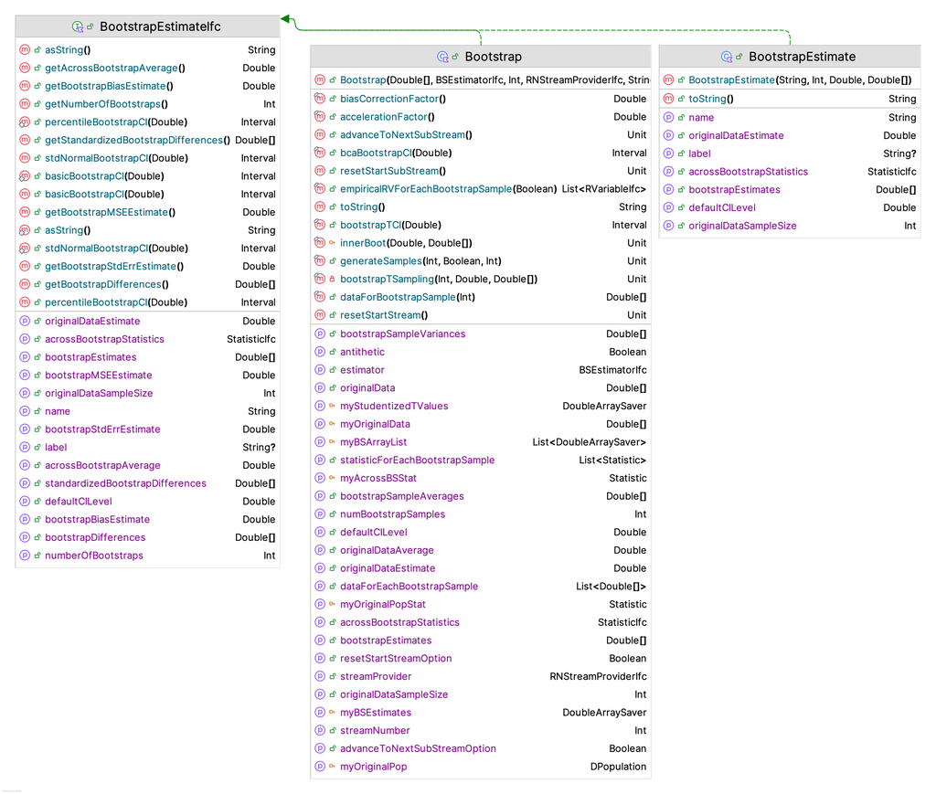

- Requires the original `DoubleArray` and a `BSEstimatorIfc` (a functional interface; built-ins: average, variance, median, min, max). It computes the replicates, bias, standard error, and the normal, basic, percentile, and BCa intervals (bootstrap-t only on request).

```kotlin
fun interface BSEstimatorIfc { fun estimate(data: DoubleArray): Double }

val bs = Bootstrap(mainSample, estimator = BSEstimatorIfc.Average(), streamNumber = 3)
bs.generateSamples(400)
println(bs)
```

```
original estimate = 3.60     bias estimate = 0.0378     std. err. = 0.8329
percentile c.i. = [2.1000, 5.3000]        BCa c.i. = [1.9000, 5.0000]
```

## Multiple Statistics and Case-Based Bootstrapping

- `BootstrapSampler` (with `MVBSEstimatorIfc`) returns **many** estimates from one sample — e.g., `BasicStatistics()` gives average, variance, min, max, skewness, kurtosis, lag-1 correlation/covariance.
- `CaseBootstrapSampler` (with `CaseBootEstimatorIfc`) samples **case identifiers** (row indices) — ideal for bootstrapping the rows of a regression data set.

```kotlin
// data rows are (y, x1, x2) with y = 10 + 2*x1 + 5*x2 + error
val cbs = CaseBootstrapSampler(MatrixBootEstimator(data, OLSBootEstimator))
val estimates = cbs.bootStrapEstimates(399)   // OLS intercept + slopes, per resample
```

```
statistic name = b0
original estimate = 10.4970      bias estimate = -0.0308
percentile c.i. = [9.2379, 11.7588]     // covers the true intercept β0 = 10.0
```

## What is a Variance Reduction Technique (VRT)?

- A VRT is a sampling strategy that reduces the variance of the **sampling distribution** of an estimator $\hat{\theta}$ of some parameter $\theta$.
- For the crude estimator of the mean, $\hat{\theta}=\bar{Y}$, with IID $Y_i$: $\;\text{Var}[\bar{Y}] = \sigma^2_Y / n$. A VRT tries to do **better** than this.
- Variance reduction is about the **estimator**, not the process: $\sigma^2_Y$ (the population variability) is unchanged — we change the variance of the *sampling distribution*.
- Two families of techniques:
  - **Manipulating randomness:** Common Random Numbers (CRN), Antithetic Variates (AV)
  - **Exploiting process knowledge:** Indirect Estimation, Control Variates, Stratified Sampling, Conditional Expectation, Importance Sampling

## Common Random Numbers (CRN)

- Used when *comparing* systems: $\theta = \theta_1 - \theta_2$, with pairs $D_i = X_i - Y_i$ and $\hat{\theta}=\bar{D}=\bar{X}-\bar{Y}$. If each alternative sees the same randomness, differences reflect a *true* difference, not noise.

$$\text{Var}[\bar{D}]=\frac{\sigma^{2}_{X}}{n} +\frac{\sigma^{2}_{Y}}{n} - 2\rho_{XY}\sigma_{X}\sigma_{Y}
\;\;\Rightarrow\;\; V_{CRN} = V_{IND} - 2\rho_{XY}\sigma_{X}\sigma_{Y}$$

- Reduction requires **positive correlation** within pairs ($\rho_{XY}>0$); it **backfires** under negative correlation. Induce positive correlation by feeding the same $U_i$ through inverse transforms: $X_i=F_X^{-1}(U_i),\,Y_i=F_Y^{-1}(U_i)$.
- **Synchronization** best practices (the KSL does these automatically): inverse-transform generation, a dedicated stream per source of randomness, and resetting each stream’s sub-stream at the start of every replication.

## Antithetic Variates (AV)

- Applies to a **single** model: induce *negative* correlation within pairs of runs $(Y_{2j-1}, Y_{2j})$.

$$\text{Var}[\hat{Y}]=\frac{\sigma^2_Y}{n}(1+\rho) \;<\; \frac{\sigma^2_Y}{n} \quad\text{when } \rho<0$$

- Recipe: alternate the stream between runs — Run 1 uses $(u_1,\cdots,u_k)$, Run 2 uses $(1-u_1,\cdots,1-u_k)$, so $X_{2j-1}=F^{-1}(u),\,X_{2j}=F^{-1}(1-u)$.
- In Monte Carlo integration the antithetic sampler is built via `sampler.antitheticInstance()`; each replication returns $\hat{Y}_j=(Y_{2j-1}+Y_{2j})/2$:

```kotlin
override fun replication(j: Int): Double {
    return if (isAntitheticOptionOn) {
        val y1 = myFunction.f(mySampler.sample())
        val y2 = myFunction.f(myAntitheticSampler!!.sample())
        (y1 + y2) / 2.0
    } else {
        myFunction.f(mySampler.sample())
    }
}
```

- Within a DEDS model, simply set the `antitheticOption` property of the `Model` class to `true`.

## Control Variates (CV): Theory

[figure not shown]

- Observe a variable $X$ with **known** mean $\mu=E[X]$ that is correlated with $Y$. Define $Z_j = Y_j + C(X_j - \mu)$; then $E[Z_j]=E[Y_j]$ — unbiased for any constant $C$.
- The optimal constant minimizes the variance: $C^{*}=-\text{cov}(Y,X)/\text{Var}(X)$, giving $\text{Var}[Z_j]=\text{Var}[Y_j](1-\rho^2_{XY})$.
- $\hat{C}^{*}$ has the form of a **regression slope** — so with $E[Y|X{=}x]=\beta_0+\beta_1(x-\mu)$, the CV estimator of $\theta=E[Y]$ is the **regression intercept** $\hat{\beta}_0$. This extends to $q$ controls via multiple regression.

## Control Variates in the KSL

- The `ControlVariateDataCollector` captures the response and the control variates (each with its known mean) across replications, then builds the regression whose intercept is the CV estimate.

```kotlin
val cvCollector = ControlVariateDataCollector(model)
cvCollector.addResponse(palletWorkCenter.totalProcessingTime, "TotalTime")
cvCollector.addControlVariate(palletWorkCenter.processingTimeRV, (8.0 + 12.0 + 15.0) / 3.0, "PalletTime")
cvCollector.addControlVariate(palletWorkCenter.numPalletsRV, (100.0 * 0.8), "NumPallets")
model.simulate()
val regressionData = cvCollector.collectedData("TotalTime", 20)   // 20 batches of size 5
val regressionResults = cvCollector.regressionResults(regressionData)
```

```
    Predictor  parameter parameterSE     TValue P-Values
 0  Intercept 494.631368    2.792054 177.156788 0.000000
```

- The CV estimate (intercept = **494.63**) differs from the crude estimate (**497.79**) and has a **smaller half-width**. Check residual normality before trusting it.

## Importance Sampling (IS)

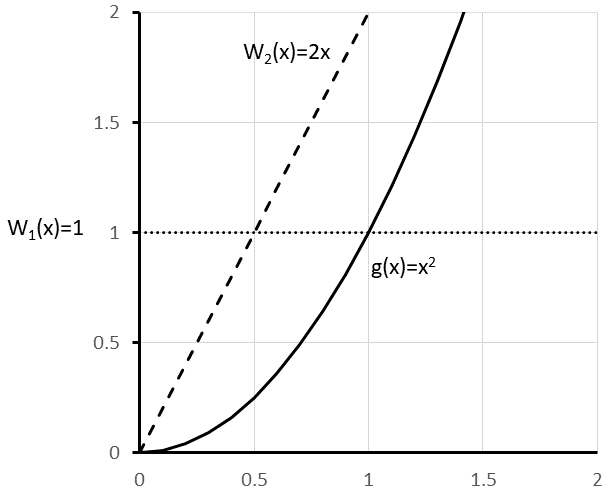

- Rewrite the integral with a **proposal density** $w(x)$ and sample $X_i \sim w(x)$:
  $$\theta = \int_a^b g(x)\,dx = \int_a^b \frac{g(x)}{w(x)}w(x)\,dx,
  \qquad \hat{\theta}=\frac{1}{n}\sum_{i=1}^{n}\frac{g(X_i)}{w(X_i)}$$
- Choose $w(x)$ to put more samples where $g(x)$ is large. For $g(x)=x^2$ on $[0,1]$, using $w(x)=2x$ instead of $U(0,1)$ gives $VR = \tfrac{1/72}{4/45}\ll 1$ — a dramatic reduction because $w(x)$ is *close in shape* to $g(x)$.
- KSL support: `MC1DIntegration` and `MCMultiVariateIntegration` let you supply $h(x)=g(x)/w(x)$, where $w(x)$ is the sampler’s distribution.

## Generating from a Bivariate Normal

- $(X_1,X_2)\sim BVN(\mu_1,\sigma^2_1,\mu_2,\sigma^2_2,\rho)$ is generated from two independent standard normals $Z_1,Z_2$:
  $$X_1 = \sigma_1 Z_1 + \mu_1, \qquad X_2 = \sigma_2\big(\rho Z_1 + \sqrt{1-\rho^2}\,Z_2\big) + \mu_2$$
- The KSL `BivariateNormalRV` implements exactly this in `generate()`:

```kotlin
override fun generate(array: DoubleArray) {
    val z0 = Normal.stdNormalInvCDF(rnStream.randU01())
    val z1 = Normal.stdNormalInvCDF(rnStream.randU01())
    val s1 = sqrt(v1)
    val s2 = sqrt(v2)
    array[0] = mean1 + s1 * z0
    array[1] = mean2 + s2 * (corr * z0 + sqrt(1.0 - corr * corr) * z1)
}
```

- **Key takeaway:** we now have a procedure for generating *correlated* random variables — the basis for the general methods that follow.

## The KSL Multi-Variate Sampling Framework

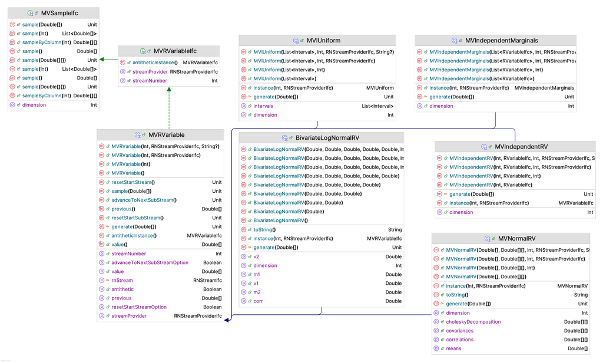

- Multi-variate variables sub-class `MVRVariable` (implementing `MVRVariableIfc` and `MVSampleIfc`) and override `generate(array: DoubleArray)` — you are simply **generating arrays** of data.
- `MVSampleIfc` mirrors the 1-D interfaces: `sample(): DoubleArray`, `sample(sampleSize): List<DoubleArray>`, `sampleByColumn(sampleSize)`. The `dimension` property gives the array size (2 for a BVN).
- The general $d$-dimensional multi-variate normal (`MVNormalRV`) extends the BVN algorithm using the **Cholesky decomposition** $\Sigma = CC^{T}$: $\;X_i = \mu_i + \sum_{j=1}^{i} c_{ij}Z_j$.

## Copulas and Sklar’s Theorem

- **Copula:** a CDF $C:[0,1]^d \to [0,1]$ with **uniform marginals** — the joint CDF of *dependent* uniforms $(U_1,\cdots,U_d)$.
- **Sklar’s Theorem:** any joint CDF can be written as a copula of its marginals,
  $$F(x_1,\cdots,x_d) = C\big(F_1(x_1),\cdots,F_d(x_d)\big)$$
  (unique when the marginals are continuous).
- This **separates the dependence structure (the copula) from the marginals**. General recipe for correlated vectors:
  1. Specify a copula and its parameters
  2. Generate $\vec{U}=(u_1,\cdots,u_d)$ from the copula
  3. Set $Y_i = F_i^{-1}(u_i)$ — inverse transform each marginal
- The **Gaussian copula** is extracted from the MVN: $C^G_{\mathbf{P}}(\vec{u}) = \Phi_{\mathbf{P}}\big(\Phi^{-1}(u_1),\cdots,\Phi^{-1}(u_d)\big)$.

## The Gaussian Copula in the KSL

- `MVGaussianCopula` generates the dependent uniforms; `MVGaussianCopulaRV` completes the recipe by applying the user-supplied inverse-CDF marginals. The marginals need **not** be from the same family and may be discrete or continuous.

```kotlin
class MVGaussianCopulaRV(
    val marginals: List<InverseCDFIfc>,
    correlation: Array<DoubleArray>,
    // ... stream parameters
) : MVRVariable(/* ... */) {

    private val myCopula = MVGaussianCopula(correlation, stream)

    override fun generate(array: DoubleArray) {
        val u = myCopula.sample()                       // dependent uniforms from the copula
        for (i in u.indices) {
            array[i] = marginals[i].invCDF(u[i])        // inverse transform each marginal
        }
    }
}
```

## Autocorrelated Generation: NORTA and AR(1)

- Ignoring correlation that is actually present in an input process can **grossly** distort performance estimates. The **Normal-to-Anything (NORTA)** transform generates correlated variates of any marginal:
  $$X_i = F^{-1}\big(\Phi(Z_i)\big)$$
  Correlated $Z_i$ produce correlated $X_i$ (though $\rho_x \neq \rho_z$ in general).
- Induce correlation in the $Z_i$ with a stationary **AR(1)** process: $Z_i = \phi Z_{i-1} + \varepsilon_i$, with $\varepsilon_i \sim N(0,1-\phi^2)$ and lag-1 correlation $\phi$.
- `AR1CorrelatedRNStream` packages this as a **stream** you can hand to any random variable:

```kotlin
class AR1CorrelatedRNStream(
    val lag1Corr: Double,
    private val stream: RNStreamIfc = KSLRandom.nextRNStream(),
) : RNStreamIfc by stream {
    // myX starts as N(0,1); errorVariance = 1 - lag1Corr^2
    override fun randU01(): Double {
        val e = KSLRandom.rNormal(0.0, errorVariance, stream)
        myX = lag1Corr * myX + e
        return Normal.stdNormalCDF(myX)      // correlated U(0,1) via the normal CDF
    }
}
```

## Why Markov Chain Monte Carlo (MCMC) Works

- MCMC approximately generates variates from **arbitrary** distributions — even ones known only **up to a multiplicative constant** (crucial in Bayesian work) — and works for multi-variate targets.
- The Monte Carlo estimator $\hat{\theta}=\frac{1}{n}\sum_{i=1}^{n} h(X_i)$ converges to $\theta$ even when the $X_i$ are **dependent**, under mild conditions.
- Idea: build a Markov chain whose **limiting distribution** is the target $w(\vec{x})$ (often written $\pi(\vec{x})$). For an irreducible, aperiodic chain,
  $$\lim_{n \to \infty}\frac{1}{n}\sum_{i=1}^{n}h(X_i)=\sum_{j=1}^{N}h(j)\pi_j \quad \text{w.p. } 1$$
- So instead of needing $\pi_j$ in closed form, we run a chain that *has* $\pi_j$ as its steady state.

## Discrete Markov Chains

- A chain has the **Markov property** — the next state depends only on the current state — with single-step transition probabilities $p_{ij}=P\{X_{n+1}=j \mid X_n=i\}$.
- `DMarkovChain` (in `ksl.utilities.random.markovchain`) simulates a discrete-state chain from its transition matrix:

```kotlin
val p = arrayOf(
    doubleArrayOf(0.3, 0.1, 0.6),
    doubleArrayOf(0.4, 0.4, 0.2),
    doubleArrayOf(0.1, 0.7, 0.2)
)
val mc = DMarkovChain(1, p)          // initial state = 1
val f = IntegerFrequency()
for (i in 1..100000) {
    f.collect(mc.nextState())
}
println(f)
```

- The observed proportions $(0.278, 0.411, 0.311)$ converge to the true steady-state distribution $\pi = (0.279, 0.410, 0.311)$.

## The Metropolis-Hastings Algorithm

- MCMC **turns the usual problem around:** given a *desired* $\pi_j$, construct a transition scheme $\mathbf{P}$ that produces it. Use an arbitrary proposal $\mathbf{Q}$ and accept/reject moves.
- Discrete acceptance probability — note it needs $\pi$ only **up to a constant** (ratio form):
  $$\alpha_{ij} = \min\!\bigg[\frac{\pi_j q_{ji}}{\pi_i q_{ij}},\,1\bigg]$$
- Continuous / multi-variate: target $f(\vec{x})$, proposal $q(\vec{y}\mid\vec{x})$, acceptance ratio
  $$\rho(\vec{x},\vec{y}) = \frac{q(\vec{x}\mid\vec{y})\,f(\vec{y})}{q(\vec{y}\mid\vec{x})\,f(\vec{x})},
  \qquad \alpha(\vec{x},\vec{y})=\min[\rho,\,1]$$
- **Each step:** propose $\vec{Y}\sim q(\vec{y}\mid\vec{x})$; draw $U\sim U(0,1)$; set $X_{t+1}=\vec{Y}$ if $U\le\alpha$, else stay at $X_t$.

## Samplers and the KSL Interfaces

- `MetropolisHastingsMV` is supported by two interfaces:
  - `FunctionMVIfc` — the target density $f(\vec{x})$ via `f(x: DoubleArray)`
  - `ProposalFunctionMVIfc` — `generateProposedGivenCurrent()` and `proposalRatio()` for $p_r(\vec{x},\vec{y})=q(\vec{x}\mid\vec{y})/q(\vec{y}\mid\vec{x})$
- **Independence sampler:** $q(\vec{y}\mid\vec{x})=q(\vec{y})$, so $\rho = \dfrac{q(\vec{x})\,f(\vec{y})}{q(\vec{y})\,f(\vec{x})}$. Good proposals resemble $f$.
- **Random-walk sampler:** $\vec{Y}=\vec{x}+\vec{W}$ with $\vec{W}$ symmetric. If the proposal stays symmetric, $p_r = 1$ and $\rho = f(\vec{y})/f(\vec{x})$; a bounded range can break the symmetry (see the example).

## The `MetropolisHastingsMV` Class

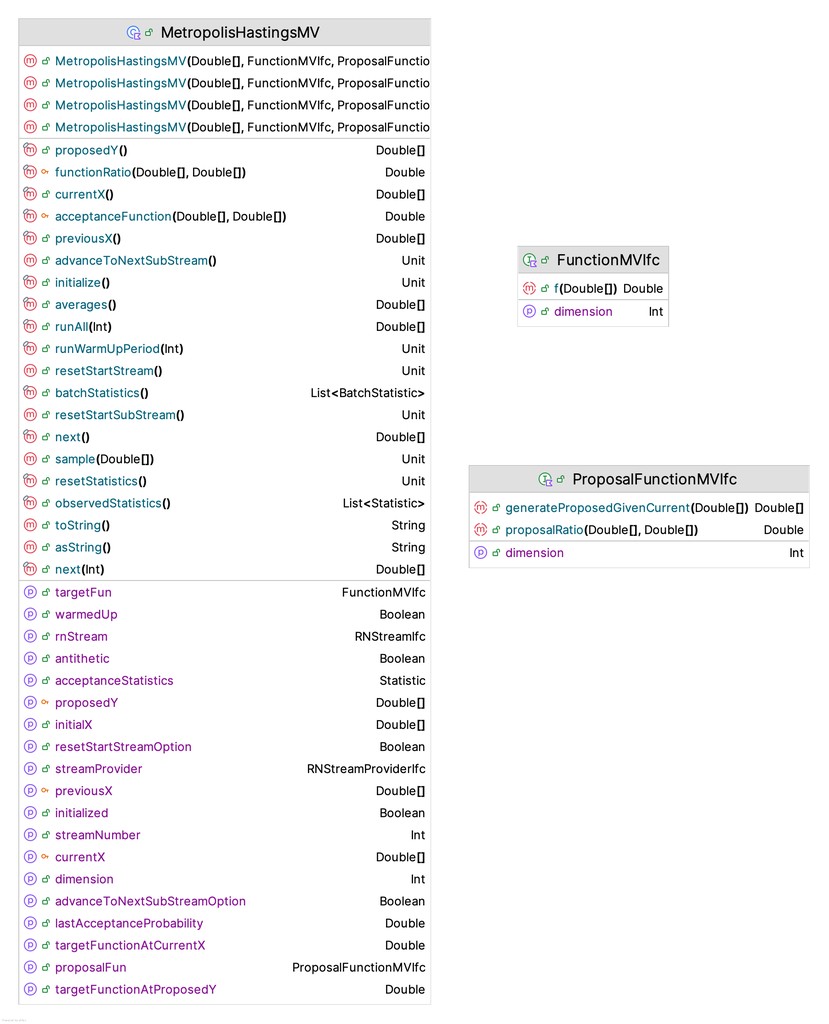

## MCMC Example: Independence Sampler

- Target: the ore-content joint density $f(x_1,x_2)$ (zinc $\in[0.5,1.5]$, iron $\in[20,35]$), implemented as a `FunctionMVIfc`:

```kotlin
object Function : FunctionMVIfc {
    override val dimension: Int get() = 2
    override fun f(x: DoubleArray): Double {
        val x0p = 17.0 * (x[0] - 1.0) * (x[0] - 1.0) / 50.0
        val x1p = (x[1] - 25.0) * (x[1] - 25.0) / 10000.0
        return (39.0 / 400.0) - x0p - x1p
    }
}
```

- Proposal `ExampleIndependencePF` uses independent `GeneralizedBeta` marginals over the two ranges (`proposalRatio` = $g(\vec{x})/g(\vec{y})$). Run it:

```kotlin
val m = MetropolisHastingsMV(doubleArrayOf(1.0, 27.5), Function, ExampleIndependencePF)
m.runWarmUpPeriod(10000)   // burn-in
m.runAll(10000)
```

```
Acceptance Statistics: avg = 0.3648
BatchStatistic{name='X_1', avg=0.9605, ci=[0.9305, 0.9904], lag-1 corr=0.063}
BatchStatistic{name='X_2', avg=26.295, ci=[25.789, 26.802], lag-1 corr=0.028}
```

## Why the Independence Sampler Mixes Poorly

- The true means are $E[X_1] = 1.0$ and $E[X_2] = 1751/64 \approx 27.36$. **Both intervals miss them.**
- 6,352 of the 10,000 observations repeat the previous state; one state repeats **286 times** in a row.
- The cause is the proposal: the beta(2, 5) density is nearly 0 near the **upper end** of each range, where $f(\vec{x})$ is not small.
  - Those states are rarely proposed, and once the chain reaches one, nearly every proposal is rejected, so the chain sticks.
  - On balance the region is under-sampled, so the estimated means are too small.
- A good independence proposal **resembles** $f(\vec{x})$. Exercise 9.19 asks you to design a better one.

## MCMC Example: Random-Walk Sampler

- Propose $y_i = x_i + e_i$ with $e_i \sim U(-c_i, c_i)$; `genYGivenX()` **redraws** until $y_i$ lands inside the range $[a_i, b_i]$.
- So $y_i$ is uniform on the part of $[x_i - c_i, x_i + c_i]$ inside the range. Its length is
  $$L_i(x_i) = \min(b_i, x_i + c_i) - \max(a_i, x_i - c_i), \qquad q(y_i \mid x_i) = 1/L_i(x_i)$$
- Near a boundary $L_i$ shrinks, so the proposal is **not symmetric** and
  $$p_r(\vec{x},\vec{y}) = \frac{L_1(x_1)\,L_2(x_2)}{L_1(y_1)\,L_2(y_2)}$$
- For $X_1$, $c_1 = 1$ covers $[0.5, 1.5]$ from anywhere, so $L_1 = 1$. For $X_2$ ($c_2 = 5$), the ratio matters within 5 of 20 or 35. Using $p_r = 1$ would bias the chain near the boundaries.

## Random-Walk Sampler: Code and Results

```kotlin
object ExampleRandomWalkPF : ProposalFunctionMVIfc {
    private val y1Interval = Interval(0.5, 1.5)
    private val y2Interval = Interval(20.0, 35.0)
    private val y1c = 1.0
    private val y2c = 5.0
    // e1rv ~ U(-y1c, y1c), e2rv ~ U(-y2c, y2c); genYGivenX() keeps x + e in range
    override fun proposalRatio(currentX: DoubleArray, proposedY: DoubleArray): Double {
        val lx = windowLength(y1Interval, y1c, currentX[0]) * windowLength(y2Interval, y2c, currentX[1])
        val ly = windowLength(y1Interval, y1c, proposedY[0]) * windowLength(y2Interval, y2c, proposedY[1])
        return (lx / ly)                               // L(x)/L(y)
    }
    private fun windowLength(interval: Interval, c: Double, x: Double): Double {
        return minOf(interval.upperLimit, x + c) - maxOf(interval.lowerLimit, x - c)
    }
}
```

```
Acceptance Statistics: avg = 0.7650
BatchStatistic{name='X_1', avg=0.9943, ci=[0.9881, 1.0005], lag-1 corr=0.022}
BatchStatistic{name='X_2', avg=27.274, ci=[27.031, 27.518], lag-1 corr=0.064}
```

- Acceptance 0.77 versus 0.36, both intervals **contain the true means**, and only 2,350 repeats (longest run 8): **better mixing**. The KSL reports **batch** statistics because MCMC output is correlated.

## Summary: Key KSL Classes

- **Bootstrapping** (`ksl.utilities.statistics`): `Bootstrap`, `BootstrapSampler`, `CaseBootstrapSampler` — with `BSEstimatorIfc`, `MVBSEstimatorIfc`, `CaseBootEstimatorIfc`.
- **Variance reduction:** random number streams; `ReplicationDataCollector` and `ControlVariateDataCollector`; Monte Carlo integration in `ksl.utilities.mcintegration` (`MC1DIntegration`, `antitheticOption`).
- **Multi-variate / correlated generation** (`ksl.utilities.rvariable`): `MVRVariable` / `MVSampleIfc`, `BivariateNormalRV`, `MVNormalRV`, `MVGaussianCopula`, `MVGaussianCopulaRV`, `AR1CorrelatedRNStream`.
- **MCMC:** `DMarkovChain` (`ksl.utilities.random.markovchain`); `MetropolisHastingsMV` with `FunctionMVIfc` and `ProposalFunctionMVIfc` (`ksl.utilities.random.mcmc`).
- The KSL provides immediately useful implementations and a structure that makes it easy to add your own.

⌂ Index